# Uvod v ponovljivo znanost, dplyr in git

Roman Luštrik in Črt Ahlin

10.2.2015

V tem tutorialu bomo stopali po stopinjah, kot so jih zagazili v [Introduction to dplyr for Faster Data Manipulation in R](https://rpubs.com/justmarkham/dplyr-tutorial).

```r
library(dplyr)
```

```r
library(hflights)
library(ggplot2)
library(nycflights13)

fl <- tbl_df(hflights)
```

`hflights` so podatki odhodov s Houstonskega letališča.

```r
print(fl)
```

```
## Source: local data frame [227,496 x 21]
##
##    Year Month DayofMonth DayOfWeek DepTime ArrTime UniqueCarrier FlightNum
## 1  2011     1          1         6    1400    1500            AA       428
## 2  2011     1          2         7    1401    1501            AA       428
## 3  2011     1          3         1    1352    1502            AA       428
## 4  2011     1          4         2    1403    1513            AA       428
## 5  2011     1          5         3    1405    1507            AA       428
## 6  2011     1          6         4    1359    1503            AA       428
## 7  2011     1          7         5    1359    1509            AA       428
## 8  2011     1          8         6    1355    1454            AA       428
## 9  2011     1          9         7    1443    1554            AA       428
## 10 2011     1         10         1    1443    1553            AA       428
## ..  ...   ...        ...       ...     ...     ...           ...       ...
## Variables not shown: TailNum (chr), ActualElapsedTime (int), AirTime
##   (int), ArrDelay (int), DepDelay (int), Origin (chr), Dest (chr),
##   Distance (int), TaxiIn (int), TaxiOut (int), Cancelled (int),
##   CancellationCode (chr), Diverted (int)
```

Glagoli, ki jih uporabljamo za manipulacijo s podatki so:

- `filter` izbira vrstice glede na argument
- `select` izbira stolpce glede na argument
- `arrange` sortira podatke
- `mutate` dodaja spremenljivke
- `summarize` povzema spremenljivke v eno številko

## filter

Filter izbira vrstice, ki zadostijo določenim pogojem. Na voljo imamo vse R-jeve logične operatorje.

Najdimo vse lete, ki so pristali na letališčih LEX ali JFK.

```r
# "osnovni" R način
lex.jfk <- hflights[hflights$Dest %in% c("LEX", "JFK"), ]
# with(hflights, hflights[Dest %in% c("LEX", "JFK"), ])
head(lex.jfk)
```

```
##       Year Month DayofMonth DayOfWeek DepTime ArrTime UniqueCarrier
## 57719 2011     1          1         6     654    1124            B6
## 57720 2011     1          1         6    1639    2110            B6
## 58343 2011     1          2         7     703    1113            B6
## 58344 2011     1          2         7    1604    2040            B6
## 58983 2011     1          3         1     659    1100            B6
## 58984 2011     1          3         1    1801    2200            B6
##       FlightNum TailNum ActualElapsedTime AirTime ArrDelay DepDelay Origin
## 57719       620  N324JB               210     181        5       -6    HOU
## 57720       622  N324JB               211     188       61       54    HOU
## 58343       620  N324JB               190     172       -6        3    HOU
## 58344       622  N324JB               216     176       31       19    HOU
## 58983       620  N229JB               181     166      -19       -1    HOU
## 58984       622  N206JB               179     165      111      136    HOU
##       Dest Distance TaxiIn TaxiOut Cancelled CancellationCode Diverted
## 57719  JFK     1428      6      23         0                         0
## 57720  JFK     1428     12      11         0                         0
## 58343  JFK     1428      6      12         0                         0
## 58344  JFK     1428      9      31         0                         0
## 58983  JFK     1428      3      12         0                         0
## 58984  JFK     1428      5       9         0                         0
```

```r
dim(lex.jfk)
```

```
## [1] 1279   21
```

```r
lex.jfk <- filter(fl, Dest %in% c("LEX", "JFK"))
filter(fl, Dest == "LEX" | Dest == "JFK")
```

```
## Source: local data frame [1,279 x 21]
##
##    Year Month DayofMonth DayOfWeek DepTime ArrTime UniqueCarrier FlightNum
## 1  2011     1          1         6     654    1124            B6       620
## 2  2011     1          1         6    1639    2110            B6       622
## 3  2011     1          2         7     703    1113            B6       620
## 4  2011     1          2         7    1604    2040            B6       622
## 5  2011     1          3         1     659    1100            B6       620
## 6  2011     1          3         1    1801    2200            B6       622
## 7  2011     1          4         2     654    1103            B6       620
## 8  2011     1          4         2    1608    2034            B6       622
## 9  2011     1          5         3     700    1103            B6       620
## 10 2011     1          5         3    1544    1954            B6       624
## ..  ...   ...        ...       ...     ...     ...           ...       ...
## Variables not shown: TailNum (chr), ActualElapsedTime (int), AirTime
##   (int), ArrDelay (int), DepDelay (int), Origin (chr), Dest (chr),
##   Distance (int), TaxiIn (int), TaxiOut (int), Cancelled (int),
##   CancellationCode (chr), Diverted (int)
```

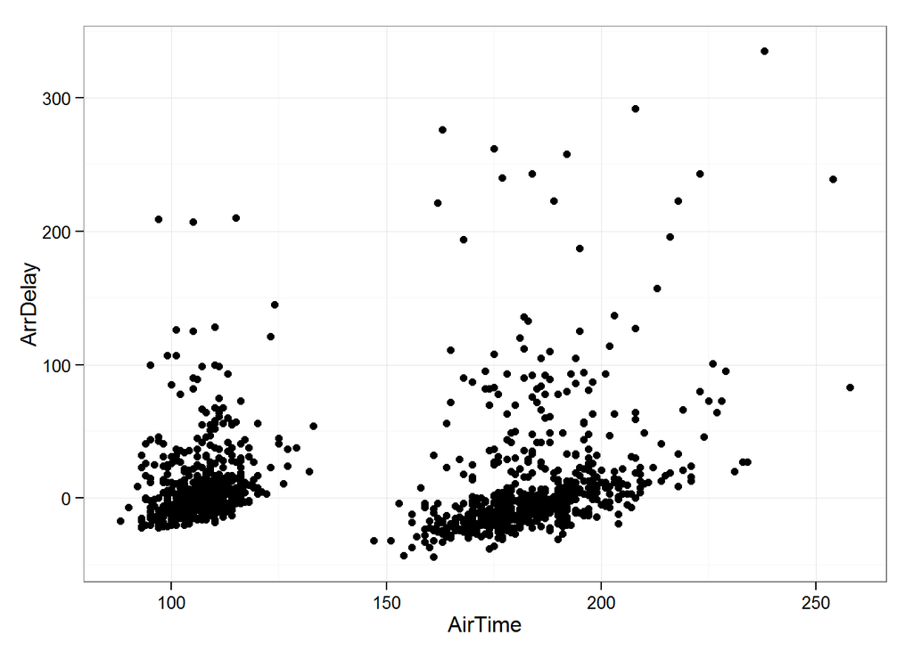

```r
ggplot(lex.jfk, aes(x = AirTime, y = ArrDelay)) +
  theme_bw() +
  geom_point()
```

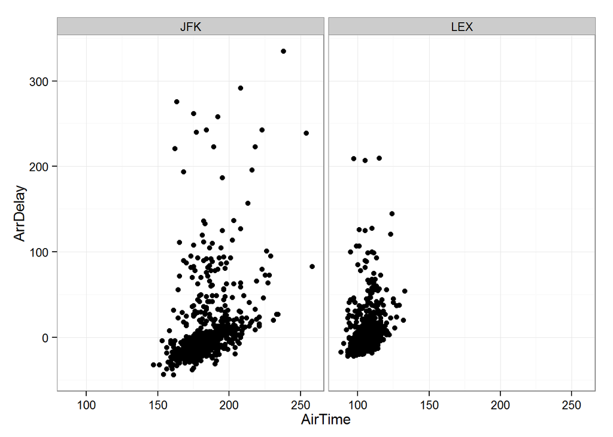

```r
ggplot(lex.jfk, aes(x = AirTime, y = ArrDelay)) +
  theme_bw() +
  geom_point() +
  facet_wrap(~ Dest)
```

Poglejmo vse lete, ki so odleteli v januarju.

```r
filter(fl, Month == "1")
```

```
## Source: local data frame [18,910 x 21]
##
##    Year Month DayofMonth DayOfWeek DepTime ArrTime UniqueCarrier FlightNum
## 1  2011     1          1         6    1400    1500            AA       428
## 2  2011     1          2         7    1401    1501            AA       428
## 3  2011     1          3         1    1352    1502            AA       428
## 4  2011     1          4         2    1403    1513            AA       428
## 5  2011     1          5         3    1405    1507            AA       428
## 6  2011     1          6         4    1359    1503            AA       428
## 7  2011     1          7         5    1359    1509            AA       428
## 8  2011     1          8         6    1355    1454            AA       428
## 9  2011     1          9         7    1443    1554            AA       428
## 10 2011     1         10         1    1443    1553            AA       428
## ..  ...   ...        ...       ...     ...     ...           ...       ...
## Variables not shown: TailNum (chr), ActualElapsedTime (int), AirTime
##   (int), ArrDelay (int), DepDelay (int), Origin (chr), Dest (chr),
##   Distance (int), TaxiIn (int), TaxiOut (int), Cancelled (int),
##   CancellationCode (chr), Diverted (int)
```

Izberimo lete, ki so odleteli v januarju, čas potovanja pa je bil krajši od ene ure.

```r
jan.ura <- filter(fl, Month == "1", ActualElapsedTime <= 60)
summary(jan.ura)
```

```
##       Year          Month     DayofMonth     DayOfWeek        DepTime
##  Min.   :2011   Min.   :1   Min.   : 1.0   Min.   :1.000   Min.   :   4
##  1st Qu.:2011   1st Qu.:1   1st Qu.: 8.0   1st Qu.:2.000   1st Qu.:1044
##  Median :2011   Median :1   Median :16.0   Median :4.000   Median :1514
##  Mean   :2011   Mean   :1   Mean   :15.9   Mean   :3.953   Mean   :1472
##  3rd Qu.:2011   3rd Qu.:1   3rd Qu.:24.0   3rd Qu.:6.000   3rd Qu.:1851
##  Max.   :2011   Max.   :1   Max.   :31.0   Max.   :7.000   Max.   :2335
##     ArrTime     UniqueCarrier        FlightNum      TailNum
##  Min.   :   1   Length:2730        Min.   :   1   Length:2730
##  1st Qu.:1135   Class :character   1st Qu.:  56   Class :character
##  Median :1603   Mode  :character   Median :1441   Mode  :character
##  Mean   :1547                      Mean   :1411
##  3rd Qu.:1936                      3rd Qu.:2568
##  Max.   :2359                      Max.   :3848
##  ActualElapsedTime    AirTime         ArrDelay          DepDelay
##  Min.   :35.00     Min.   :23.00   Min.   :-42.000   Min.   :-17.000
##  1st Qu.:50.00     1st Qu.:34.00   1st Qu.: -7.000   1st Qu.: -2.000
##  Median :54.00     Median :40.00   Median : -2.000   Median :  1.000
##  Mean   :53.28     Mean   :38.66   Mean   :  4.485   Mean   :  9.109
##  3rd Qu.:57.00     3rd Qu.:43.00   3rd Qu.:  9.000   3rd Qu.: 12.000
##  Max.   :60.00     Max.   :52.00   Max.   :204.000   Max.   :211.000
##     Origin              Dest              Distance         TaxiIn
##  Length:2730        Length:2730        Min.   :127.0   Min.   : 1.000
##  Class :character   Class :character   1st Qu.:191.0   1st Qu.: 3.000
##  Mode  :character   Mode  :character   Median :217.0   Median : 4.000
##                                        Mean   :219.3   Mean   : 3.964
##                                        3rd Qu.:239.0   3rd Qu.: 5.000
##                                        Max.   :393.0   Max.   :14.000
##     TaxiOut        Cancelled CancellationCode      Diverted
##  Min.   : 4.00   Min.   :0   Length:2730        Min.   :0
##  1st Qu.: 8.00   1st Qu.:0   Class :character   1st Qu.:0
##  Median :10.00   Median :0   Mode  :character   Median :0
##  Mean   :10.66   Mean   :0                      Mean   :0
##  3rd Qu.:13.00   3rd Qu.:0                      3rd Qu.:0
##  Max.   :26.00   Max.   :0                      Max.   :0
```

Poglejmo lete, kjer je nedvoumna oznaka letalske družbe UA ali YV, hkrati pa je čas potovanja krajši od dveh ur.

```r
filter(fl, (UniqueCarrier == "UA" | UniqueCarrier == "YV") & ActualElapsedTime <= 120) # oklepaji!
```

```
## Source: local data frame [2 x 21]
##
##   Year Month DayofMonth DayOfWeek DepTime ArrTime UniqueCarrier FlightNum
## 1 2011     7         24         7    2318      12            UA       774
## 2 2011    11         20         7    1002    1144            UA       242
## Variables not shown: TailNum (chr), ActualElapsedTime (int), AirTime
##   (int), ArrDelay (int), DepDelay (int), Origin (chr), Dest (chr),
##   Distance (int), TaxiIn (int), TaxiOut (int), Cancelled (int),
##   CancellationCode (chr), Diverted (int)
```

Kaj izberemo s tem ukazom?

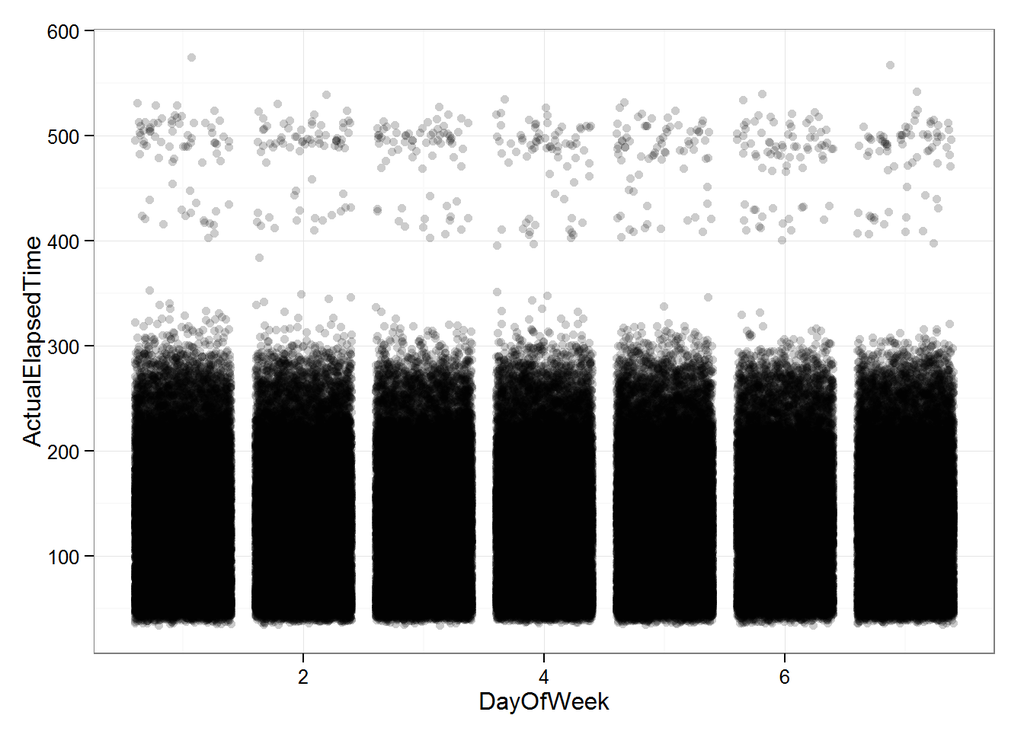

```r
mis1 <- filter(fl, (DayOfWeek == 1 & ActualElapsedTime >= 400) | (DayOfWeek == 7 & ActualElapsedTime < 300))

ggplot(fl, aes(x = DayOfWeek, y = ActualElapsedTime)) +
  theme_bw() +
  geom_jitter(alpha = 0.2)
```

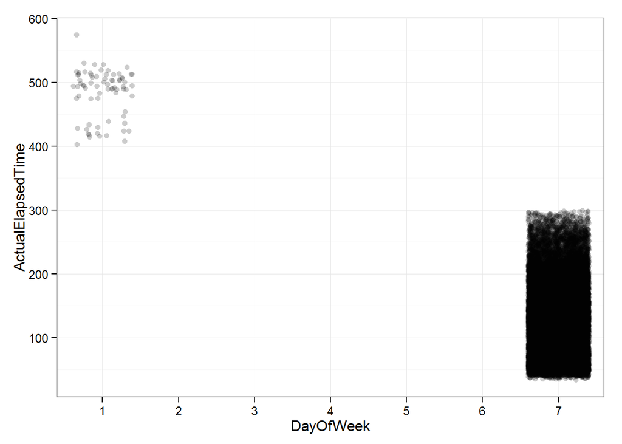

```r
ggplot(mis1, aes(x = DayOfWeek, y = ActualElapsedTime)) +
  theme_bw() +
  geom_jitter(alpha = 0.2) +
  scale_x_discrete(drop = FALSE, limits = 1:7)
```

## select

Izbiranje stolpcev; v pomoč so nam funkcije `starts_with`, `ends_with`, `matches` in `contains`. Za razliko od “osnovnega R-ja”, znotraj funkcij ni potrebno pisati imena stolpcev v narekovajih. Podobnega smo vajeni že iz paketa `ggplot2`.

```r
fl[1:6, c("Year", "FlightNum", "Origin", "Diverted")]
```

```
## Source: local data frame [6 x 4]
##
##   Year FlightNum Origin Diverted
## 1 2011       428    IAH        0
## 2 2011       428    IAH        0
## 3 2011       428    IAH        0
## 4 2011       428    IAH        0
## 5 2011       428    IAH        0
## 6 2011       428    IAH        0
```

```r
# dplyr način
select(fl, Year, FlightNum, Origin, Diverted)
```

```
## Source: local data frame [227,496 x 4]
##
##    Year FlightNum Origin Diverted
## 1  2011       428    IAH        0
## 2  2011       428    IAH        0
## 3  2011       428    IAH        0
## 4  2011       428    IAH        0
## 5  2011       428    IAH        0
## 6  2011       428    IAH        0
## 7  2011       428    IAH        0
## 8  2011       428    IAH        0
## 9  2011       428    IAH        0
## 10 2011       428    IAH        0
## ..  ...       ...    ...      ...
```

```r
select(fl, one_of(c("Year", "FlightNum", "Origin", "Diverted")))
```

```
## Source: local data frame [227,496 x 4]
##
##    Year FlightNum Origin Diverted
## 1  2011       428    IAH        0
## 2  2011       428    IAH        0
## 3  2011       428    IAH        0
## 4  2011       428    IAH        0
## 5  2011       428    IAH        0
## 6  2011       428    IAH        0
## 7  2011       428    IAH        0
## 8  2011       428    IAH        0
## 9  2011       428    IAH        0
## 10 2011       428    IAH        0
## ..  ...       ...    ...      ...
```

Izberimo stolpcez imeni, kjer se končajo s “Time”.

```r
select(fl, ends_with("Time"))
```

```
## Source: local data frame [227,496 x 4]
##
##    DepTime ArrTime ActualElapsedTime AirTime
## 1     1400    1500                60      40
## 2     1401    1501                60      45
## 3     1352    1502                70      48
## 4     1403    1513                70      39
## 5     1405    1507                62      44
## 6     1359    1503                64      45
## 7     1359    1509                70      43
## 8     1355    1454                59      40
## 9     1443    1554                71      41
## 10    1443    1553                70      45
## ..     ...     ...               ...     ...
```

Lahko tudi kombiniramo več argumentov.

```r
select(fl, ends_with("Time"), starts_with("Taxi"))
```

```
## Source: local data frame [227,496 x 6]
##
##    DepTime ArrTime ActualElapsedTime AirTime TaxiIn TaxiOut
## 1     1400    1500                60      40      7      13
## 2     1401    1501                60      45      6       9
## 3     1352    1502                70      48      5      17
## 4     1403    1513                70      39      9      22
## 5     1405    1507                62      44      9       9
## 6     1359    1503                64      45      6      13
## 7     1359    1509                70      43     12      15
## 8     1355    1454                59      40      7      12
## 9     1443    1554                71      41      8      22
## 10    1443    1553                70      45      6      19
## ..     ...     ...               ...     ...    ...     ...
```

Stolpce lahko filtriramo tudi na podlagi izrazov (`regular expression`). Z ukazom `".th$"` izberemo vse stolpce, katerih imena se končajo s “th”.

```r
select(fl, matches(".th$"))
```

```
## Source: local data frame [227,496 x 2]
##
##    Month DayofMonth
## 1      1          1
## 2      1          2
## 3      1          3
## 4      1          4
## 5      1          5
## 6      1          6
## 7      1          7
## 8      1          8
## 9      1          9
## 10     1         10
## ..   ...        ...
```

Stolpce lahko izberemo tudi na osnovi pripone imena stolpca v `data.frame`-u.

```r
xy <- data.frame(envir1 = runif(5), envir2 = runif(5), envir3 = runif(5), envir4 = runif(5), envir5 = runif(5),
                 spec1 = runif(5), spec2 = runif(5), spec3 = runif(5), spec4 = runif(5), spec5 = runif(5))
xy <- tbl_df(xy)
select(xy, num_range("spec", 3:5))
```

```
## Source: local data frame [5 x 3]
##
##       spec3      spec4     spec5
## 1 0.7207233 0.47843536 0.3124942
## 2 0.2357177 0.86795464 0.9393496
## 3 0.7629365 0.07628084 0.1753542
## 4 0.4116225 0.01723846 0.5417571
## 5 0.2636846 0.91566977 0.4007035
```

## Veriženje

V tej točki je dobro, da predstavimo koncept veriženja (angl. chaining oz. pipelining). V R-ju navadno ukaze beremo od notranjih oklepajev proti zunanjim, npr.

`flights[flights$DepDelay > 60, c("UniqueCarrier", "DepDelay")]`

v osnovni R sintaksi bi se `dplyr` ukaz

`filter(select(flights, UniqueCarrier, DepDelay), DepDelay > 60)`

bral kot: izberemo stolpca `UniqueCarrier` in `DepDelay` ter ohranimo samo vrstice, ki imajo v stolpcu `DepDelay` več kot 60 minut. Obstaja pa še druga pot, kjer postopek vodimo v vrsticah.

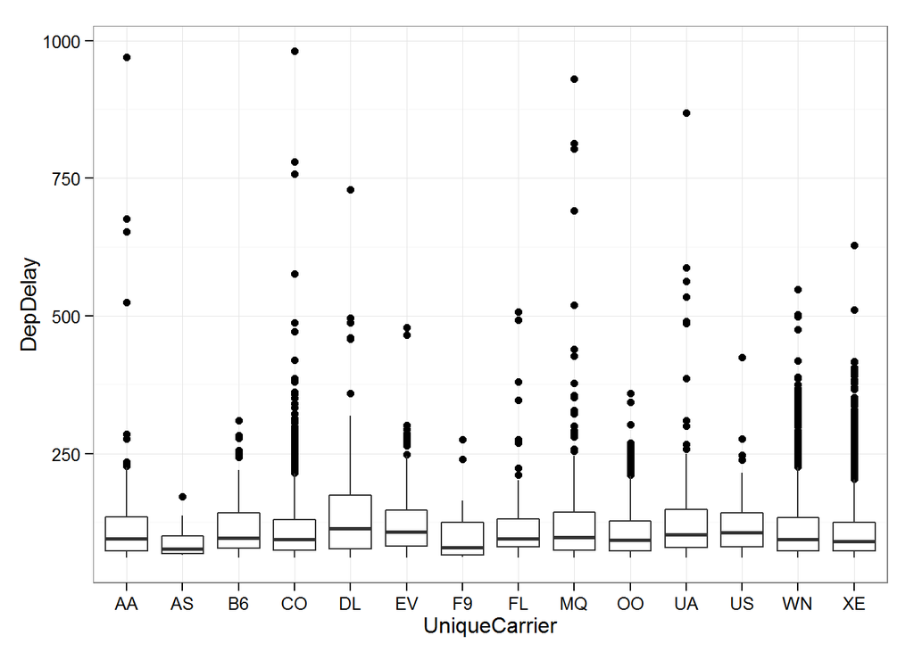

```r
uc <- fl %>%
  select(UniqueCarrier, DepDelay) %>%
  filter(DepDelay > 60)

ggplot(uc, aes(x = UniqueCarrier, y = DepDelay)) +
  theme_bw() +
  geom_boxplot()
```

Še en primer.

```r
fl %>%
  group_by(UniqueCarrier) %>%
  summarize(count = n()) %>%
  filter(count > 40000)
```

```
## Source: local data frame [3 x 2]
##
##   UniqueCarrier count
## 1            CO 70032
## 2            WN 45343
## 3            XE 73053
```

## arrange

Za sortiranje vrednosti v stolpcih (spremenljivkah) uporabimo `arrange`.

```r
fl %>%
  filter(AirTime > 500) %>%
  arrange(Month)
```

```
## Source: local data frame [14 x 21]
##
##    Year Month DayofMonth DayOfWeek DepTime ArrTime UniqueCarrier FlightNum
## 1  2011     2         20         7     931    1411            CO         1
## 2  2011     2         19         6     933    1427            CO         1
## 3  2011     2          7         1     942    1517            CO         1
## 4  2011     2          4         5     941    1428            CO         1
## 5  2011     4          7         4    1055    1435            CO         1
## 6  2011     5         14         6     944    1344            CO         1
## 7  2011     5         12         4     936    1323            CO         1
## 8  2011    10          9         7     934    1336            CO         1
## 9  2011    11         25         5     924    1408            CO         1
## 10 2011    11          9         3     937    1425            CO         1
## 11 2011    11          7         1     933    1408            CO         1
## 12 2011    12         18         7     931    1459            CO         1
## 13 2011    12          9         5     955    1447            CO         1
## 14 2011    12          1         4     936    1431            CO         1
## Variables not shown: TailNum (chr), ActualElapsedTime (int), AirTime
##   (int), ArrDelay (int), DepDelay (int), Origin (chr), Dest (chr),
##   Distance (int), TaxiIn (int), TaxiOut (int), Cancelled (int),
##   CancellationCode (chr), Diverted (int)
```

```r
fl %>%
  select(Year, Month, DayofMonth, AirTime, DepDelay) %>%
  filter(AirTime > 500) %>%
  arrange(Month, DayofMonth)
```

```
## Source: local data frame [14 x 5]
##
##    Year Month DayofMonth AirTime DepDelay
## 1  2011     2          4     507       16
## 2  2011     2          7     549       17
## 3  2011     2         19     508        8
## 4  2011     2         20     504        6
## 5  2011     4          7     502       80
## 6  2011     5         12     505        1
## 7  2011     5         14     509        9
## 8  2011    10          9     522       -1
## 9  2011    11          7     501       -2
## 10 2011    11          9     506        2
## 11 2011    11         25     503      -11
## 12 2011    12          1     518        1
## 13 2011    12          9     512       20
## 14 2011    12         18     541       -4
```

Če želimo obrniti vrstni red sortiranja (padajoče), uporabimo `desc`.

```r
fl %>%
  select(Year, Month, DayofMonth, AirTime, DepDelay) %>%
  filter(AirTime > 500) %>%
  arrange(Month, desc(DayofMonth))
```

```
## Source: local data frame [14 x 5]
##
##    Year Month DayofMonth AirTime DepDelay
## 1  2011     2         20     504        6
## 2  2011     2         19     508        8
## 3  2011     2          7     549       17
## 4  2011     2          4     507       16
## 5  2011     4          7     502       80
## 6  2011     5         14     509        9
## 7  2011     5         12     505        1
## 8  2011    10          9     522       -1
## 9  2011    11         25     503      -11
## 10 2011    11          9     506        2
## 11 2011    11          7     501       -2
## 12 2011    12         18     541       -4
## 13 2011    12          9     512       20
## 14 2011    12          1     518        1
```

## mutate

Pogosto se zgodi, da želimo izračunati novo spremenljivko na osnovi že obstoječih spremenljivk. Tu nam je v pomoč funkcija `mutate`.

Izračunajmo kakšen delež časa je letalo v zraku glede na dolžino potovanja od vrat do vrat.

```r
pat <- fl %>%
  mutate(PropAirTravel = AirTime/ActualElapsedTime) %>%
  select(PropAirTravel, ActualElapsedTime, AirTime)

pat %>%
  mutate(PropAirTravel = round(PropAirTravel * 100) %>% paste("%"))
```

```
## Source: local data frame [227,496 x 3]
##
##    PropAirTravel ActualElapsedTime AirTime
## 1           67 %                60      40
## 2           75 %                60      45
## 3           69 %                70      48
## 4           56 %                70      39
## 5           71 %                62      44
## 6           70 %                64      45
## 7           61 %                70      43
## 8           68 %                59      40
## 9           58 %                71      41
## 10          64 %                70      45
## ..           ...               ...     ...
```

```r
# spremembe naredimo v dejanskih podatkih
fl <- fl %>%
  mutate(PropAirTravel = round((AirTime/ActualElapsedTime)*100) %>% paste("%"))
```

## summarize/summarise

Če potrebujemo različne statistike glede na spremenljivke, se poslužimo funkcije `summarize`. Ta funkcionalnost je še posebej koristna v navezi z `group_by`.

```r
fl %>%
   summarize(mean = mean(AirTime, na.rm = TRUE),
             sd = sd(AirTime, na.rm = TRUE))
```

```
## Source: local data frame [1 x 2]
##
##       mean       sd
## 1 108.1423 56.55523
```

```r
(stat1 <- fl %>%
   group_by(DayofMonth, UniqueCarrier) %>%
   summarize(mean = mean(AirTime, na.rm = TRUE),
             sd = sd(AirTime, na.rm = TRUE))
 )
```

```
## Source: local data frame [464 x 4]
## Groups: DayofMonth
##
##    DayofMonth UniqueCarrier      mean        sd
## 1           1            AA  71.86869 36.715021
## 2           1            AS 251.83333 16.991085
## 3           1            B6 188.09091 14.305873
## 4           1            CO 145.84389 64.812135
## 5           1            DL  97.43373 13.847772
## 6           1            EV 101.60606 30.390220
## 7           1            F9 122.26667  8.788446
## 8           1            FL  92.47887  6.898984
## 9           1            MQ  93.25352 51.612912
## 10          1            OO 113.10833 38.062754
## ..        ...           ...       ...       ...
```

```r
stat1 %>%
  filter(UniqueCarrier == "AA")
```

```
## Source: local data frame [31 x 4]
## Groups: DayofMonth
##
##    DayofMonth UniqueCarrier     mean       sd
## 1           1            AA 71.86869 36.71502
## 2           2            AA 69.54286 36.34901
## 3           3            AA 69.45283 36.75793
## 4           4            AA 71.06061 37.29716
## 5           5            AA 69.70192 36.38571
## 6           6            AA 68.58491 35.04769
## 7           7            AA 67.46226 34.54581
## 8           8            AA 69.63208 35.31581
## 9           9            AA 69.02885 35.45993
## 10         10            AA 68.98113 37.12629
## ..        ...           ...      ...      ...
```

Če želimo prešteti število letov (vrstic) v posamezni skupini (oz. kombinaciji skupin, če v `group_by` uporabimo več spremenljivk) lahko uporabimo funkcijo `n()`.

```r
fl %>%
   group_by(DayofMonth) %>%
   summarize(count = n())
```

```
## Source: local data frame [31 x 2]
##
##    DayofMonth count
## 1           1  7411
## 2           2  7532
## 3           3  7437
## 4           4  7297
## 5           5  7223
## 6           6  7606
## 7           7  7621
## 8           8  7366
## 9           9  7467
## 10         10  7541
## ..        ...   ...
```

```r
# ekvivalentno
fl %>%
   group_by(DayofMonth) %>%
   group_size()
```

```
##  [1] 7411 7532 7437 7297 7223 7606 7621 7366 7467 7541 7578 7301 7546 7694
## [15] 7430 7389 7537 7613 7295 7599 7698 7526 7484 7234 7406 7407 7717 7777
## [29] 6697 6728 4339
```

Bližnica za kombinacijo funkcij `n()` in `group_by` je `count`.

```r
fl %>%
   count(DayofMonth)
```

```
## Source: local data frame [31 x 2]
##
##    DayofMonth    n
## 1           1 7411
## 2           2 7532
## 3           3 7437
## 4           4 7297
## 5           5 7223
## 6           6 7606
## 7           7 7621
## 8           8 7366
## 9           9 7467
## 10         10 7541
## ..        ...  ...
```

Za štetje unikatnih vrednosti v posamezni skupni (oz. kombinaciji skupin, če v `group_by` uporabimo več spremenljivk) uporabimo funkcijo `n_distinct()`.

```r
fl %>%
   group_by(DayofMonth) %>%
   summarize(unikum = n_distinct(UniqueCarrier))
```

```
## Source: local data frame [31 x 2]
##
##    DayofMonth unikum
## 1           1     15
## 2           2     15
## 3           3     15
## 4           4     14
## 5           5     15
## 6           6     15
## 7           7     15
## 8           8     15
## 9           9     15
## 10         10     15
## ..        ...    ...
```

```r
fl %>%
   group_by(DayofMonth) %>%
   n_groups()
```

```
## [1] 31
```

Za vsako destinacijo poiščemo koliko letal je opravilo koliko letov.

```r
fl %>%
   group_by(Dest) %>%
   summarize(nflights = n(), nplanes = n_distinct(TailNum))
```

```
## Source: local data frame [116 x 3]
##
##    Dest nflights nplanes
## 1   ABQ     2812     716
## 2   AEX      724     215
## 3   AGS        1       1
## 4   AMA     1297     158
## 5   ANC      125      38
## 6   ASE      125      60
## 7   ATL     7886     983
## 8   AUS     5022    1015
## 9   AVL      350     142
## 10  BFL      504      70
## ..  ...      ...     ...
```

```r
fl %>%
   group_by(Dest) %>%
   select(Cancelled) %>%
   table() %>%
   head()
```

```
##      Cancelled
## Dest     0  1
##   ABQ 2787 25
##   AEX  712 12
##   AGS    1  0
##   AMA 1265 32
##   ANC  125  0
##   ASE  120  5
```

## Vzorčenje

Vzorčenje je relativno preprosto.

```r
set.seed(357) # nastavimo zaradi ponovoljivosti
fl %>%
   sample_n(100)
```

```
## Source: local data frame [100 x 22]
##
##    Year Month DayofMonth DayOfWeek DepTime ArrTime UniqueCarrier FlightNum
## 1  2011     2          2         3      NA      NA            CO       546
## 2  2011     1         30         7    1927    2147            XE      2804
## 3  2011     4         24         7    1245    1337            WN      1147
## 4  2011     3         17         4     754    1134            XE      2432
## 5  2011     8         25         4    1011    1414            CO      1449
## 6  2011     6         26         7    2111    2246            XE      2493
## 7  2011    12         12         1    1144    1313            CO      1568
## 8  2011     9         12         1    1014    1332            OO      2013
## 9  2011    10          5         3     903     952            CO      1272
## 10 2011    12         30         5    1142    1524            OO      5182
## ..  ...   ...        ...       ...     ...     ...           ...       ...
## Variables not shown: TailNum (chr), ActualElapsedTime (int), AirTime
##   (int), ArrDelay (int), DepDelay (int), Origin (chr), Dest (chr),
##   Distance (int), TaxiIn (int), TaxiOut (int), Cancelled (int),
##   CancellationCode (chr), Diverted (int), PropAirTravel (chr)
```

Lahko vzorčimo kar delež. Tabela ima 227496 vrstic. Ena desetina je torej približno 2.275× 10<sup>4</sup> vrstic.

```r
fl %>%
   sample_frac(0.1) %>%
   nrow()
```

```
## [1] 22750
```

## Podatkovne baze

```r
# ustvarimo datoteko s končnico sqlite3
my.db <- src_sqlite("my_db.sqlite3", create = TRUE)

# v kolikor datoteka še ni naseljena z bazo, to storimo s funkcijo copy_to - v bazo kopiramo
# data.frame flights in paketa nycflights13
flights.db <- copy_to(my.db, flights, temporary = FALSE,
                        indexes = list(c("year", "month", "day"), "carrier", "tailnum"))

# flights.db <- tbl(my.db, "flights")

# dostop do baze, kjer kličemo tabelo "flights" eksplicitno preko SQL stavka
out <- tbl(my.db, sql("SELECT tailnum, distance FROM flights WHERE distance > 1000"))

# neposreden dostop do tabele "flights"
flights.db %>%
  filter(distance > 1000 & day == 5 & dest == "LAX") %>%
  mutate(speed = distance/air_time)
```

```
## Source: sqlite 3.8.6 [my_db.sqlite3]
## From: flights [527 x 17]
## Filter: distance > 1000 & day == 5 & dest == "LAX"
##
##    year month day dep_time dep_delay arr_time arr_delay carrier tailnum
## 1  2013     1   5      557        -4      858       -23      UA  N34137
## 2  2013     1   5      700         0     1014       -11      VX  N641VA
## 3  2013     1   5      710         0     1017       -14      UA  N37281
## 4  2013     1   5      836         6     1200         6      UA  N12116
## 5  2013     1   5      851        -9     1206       -14      AA  N328AA
## 6  2013     1   5      857        -3     1225        -2      DL  N705TW
## 7  2013     1   5      857        -3     1225         0      VX  N638VA
## 8  2013     1   5      939        19     1255        22      UA  N57864
## 9  2013     1   5      943        -2     1243       -15      B6  N590JB
## 10 2013     1   5     1031         1     1341         1      AA  N322AA
## ..  ...   ... ...      ...       ...      ...       ...     ...     ...
## Variables not shown: flight (int), origin (chr), dest (chr), air_time
##   (dbl), distance (dbl), hour (dbl), minute (dbl), speed (dbl)
```

```r
flights.db %>%
  group_by(month) %>%
  summarize(delay = mean(dep_delay))
```

```
## Source: sqlite 3.8.6 [my_db.sqlite3]
## From: <derived table> [?? x 2]
##
##    month     delay
## 1      1 10.036665
## 2      2 10.816843
## 3      3 13.227076
## 4      4 13.938038
## 5      5 12.986859
## 6      6 20.846332
## 7      7 21.727787
## 8      8 12.611040
## 9      9  6.722476
## 10    10  6.243988
## ..   ...       ...
```

```r
RSQLite::dbDisconnect(my.db$con) # zapre povezavo do baze
```

```
## [1] TRUE
```

```r
unlink("my_db.sqlite3") # pobriše datoteko
```